# P7

Irsyad Parama Dwiputra

2024-10-01

```r
library(ggplot2)
library(tsibble)
library(tseries)
library(MASS)
library(forecast)
library(TSA)
library(TTR)
library(aTSA)
library(graphics)
library(readxl)
```

#**Input Data**

```r
data <- read_xlsx("C:/Users/Irsyad Parama/Downloads/DATA MPDW.xlsx", sheet = "201-300")
start_date <- as.Date("20-07-2023")
end_date <- as.Date("27-10-2023")
dates <- seq.Date(from = start_date, to = end_date, by = "day")

dates <- dates[1:101]

formatted_dates <- format(dates, "%d/%m/%Y")


data <- data.frame(dates = formatted_dates, value = data[1:101, 2])
head(data)
```

```
##        dates Tavg
## 1 20/07/0020 27.9
## 2 21/07/0020 28.8
## 3 22/07/0020 29.1
## 4 23/07/0020 29.0
## 5 24/07/0020 28.8
## 6 25/07/0020 28.0
```

```r
str(data)
```

```
## 'data.frame':    101 obs. of  2 variables:
##  $ dates: chr  "20/07/0020" "21/07/0020" "22/07/0020" "23/07/0020" ...
##  $ Tavg : num  27.9 28.8 29.1 29 28.8 28 28 29 28.9 28.6 ...
```

#**Eksplorasi Data**

```r
#Objek Time Series
data.ts <- ts(data$Tavg)
data.ts
```

```
## Time Series:
## Start = 1
## End = 101
## Frequency = 1
##   [1] 27.9 28.8 29.1 29.0 28.8 28.0 28.0 29.0 28.9 28.6 28.5 28.2 28.7 29.4 29.4
##  [16] 29.6 29.4 28.8 28.8 29.0 28.7 28.3 28.6 28.8 28.2 28.4 28.4 28.8 28.2 28.2
##  [31] 28.9 29.4 29.2 28.8 29.0 29.2 28.8 29.1 29.0 28.7 28.7 28.5 28.2 28.0 28.5
##  [46] 28.9 28.3 28.4 28.7 28.7 29.0 29.3 28.4 29.1 29.6 29.5 29.2 29.5 29.3 29.1
##  [61] 29.0 29.7 28.9 29.3 28.8 28.9 28.7 29.3 29.5 29.8 30.0 30.4 29.1 28.9 29.2
##  [76] 29.2 29.0 29.8 29.3 29.6 29.7 30.1 30.7 30.1 30.2 30.1 30.3 30.8 30.1 31.8
##  [91] 30.3 30.7 29.9 30.2 30.4 29.9 29.4 29.5 30.1 30.1   NA
```

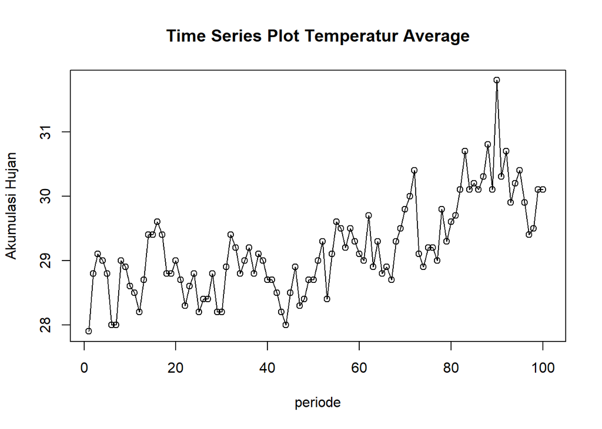

```r
#Plot Time Series
ts.plot(data.ts, xlab="periode", ylab="Akumulasi Hujan", main= "Time Series Plot Temperatur Average")
points(data.ts)
```

##**Plot Data Penuh**

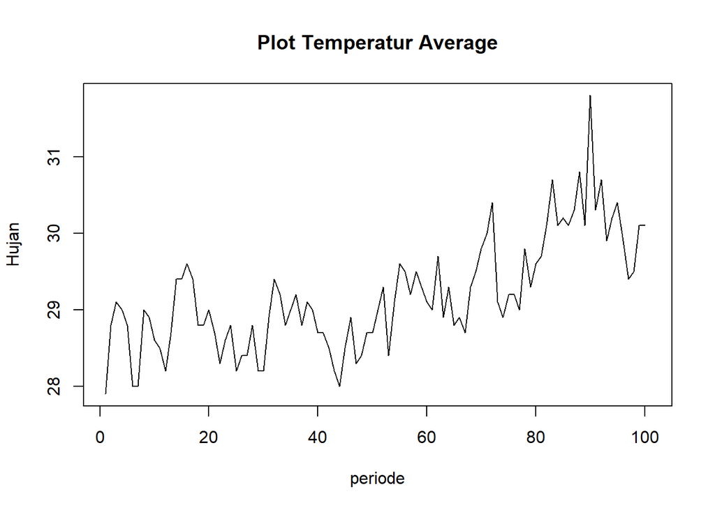

```r
plot.ts(data.ts, lty=1, xlab="periode", ylab="Hujan", main="Plot Temperatur Average")
```

##**Plot Data Latih**

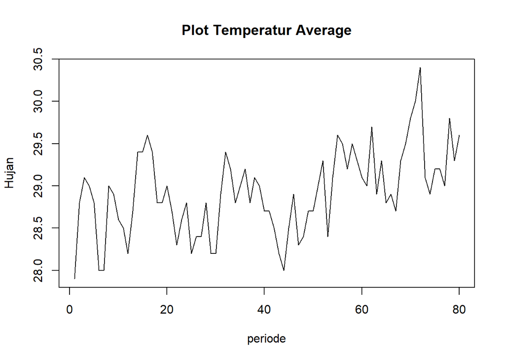

```r
datatrain <- data[1:80,]
train.ts <- ts(datatrain$Tavg)
plot.ts(train.ts, lty=1, xlab="periode", ylab="Hujan", main="Plot Temperatur Average")
```

##**Plot Data Uji**

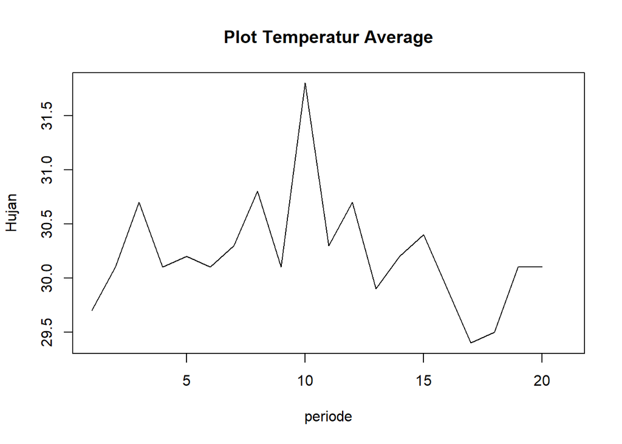

```r
datatest<-data[81:101,]
test.ts<-ts(datatest$Tavg)
plot.ts(test.ts, lty=1, xlab="periode", ylab="Hujan", main="Plot Temperatur Average")
```

#**Uji Stasioneritas Data**

##**Kestasioneran dalam Rataan**

###*Plot ACF*

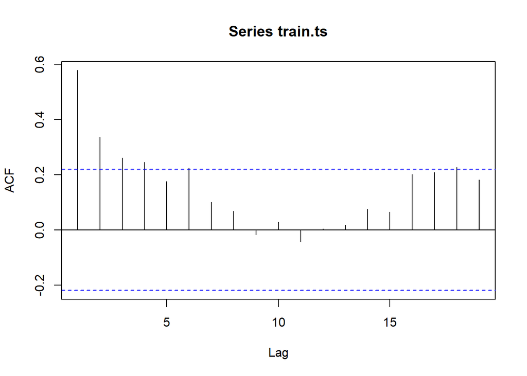

```r
acf(train.ts)
```

Berdasarkan plot ACF, terlihat bahwa plot ACF data menurun secara perlahan (*slowly decaying tails*). Hal ini juga menjadi indikasi bahwa data tidak stasioner dalam rataan

###*Uji ADF*

```r
tseries::adf.test(train.ts)
```

```
##
##  Augmented Dickey-Fuller Test
##
## data:  train.ts
## Dickey-Fuller = -3.4433, Lag order = 4, p-value = 0.05449
## alternative hypothesis: stationary
```

$H_0$ : Data tidak stasioner dalam rataan

$H_1$ : Data stasioner dalam rataan

Berdasarkan uji ADF tersebut, didapat *p-value* sebesar 0.05449 yang lebih besar dari taraf nyata 5% sehingga tak tolak $H_0$ dan menandakan bahwa data tidak stasioner dalam rataan. Hal ini sesuai dengan hasil eksplorasi menggunakan plot time series dan plot ACF, sehingga ketidakstasioneran model kedepannya harus ditangani

##**Kestasioneran dalam Ragam**

```r
index <- seq(1:80)
bc = boxcox(train.ts~index, lambda = seq(-2,by=1))
```

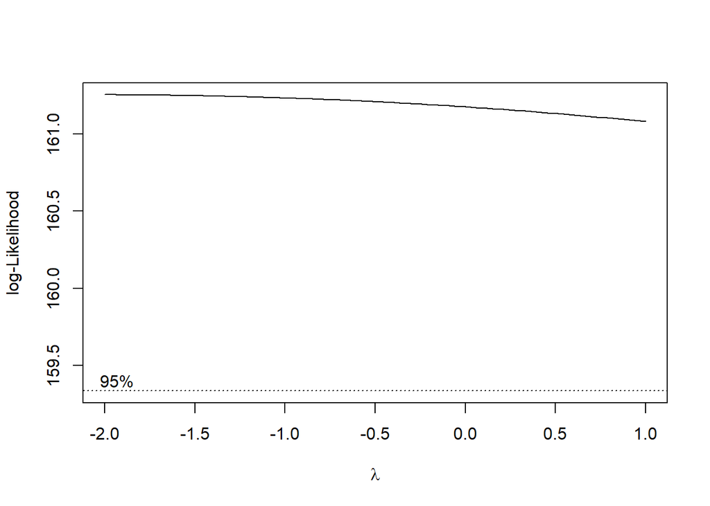

```r
lambda <- bc$x[which.max(bc$y)]
lambda
```

```
## [1] -2
```

```r
#Selang Kepercayaan
bc$x[bc$y > max(bc$y) - 1/2 * qchisq(.95,1)]
```

```
##   [1] -2.00000000 -1.96969697 -1.93939394 -1.90909091 -1.87878788 -1.84848485
##   [7] -1.81818182 -1.78787879 -1.75757576 -1.72727273 -1.69696970 -1.66666667
##  [13] -1.63636364 -1.60606061 -1.57575758 -1.54545455 -1.51515152 -1.48484848
##  [19] -1.45454545 -1.42424242 -1.39393939 -1.36363636 -1.33333333 -1.30303030
##  [25] -1.27272727 -1.24242424 -1.21212121 -1.18181818 -1.15151515 -1.12121212
##  [31] -1.09090909 -1.06060606 -1.03030303 -1.00000000 -0.96969697 -0.93939394
##  [37] -0.90909091 -0.87878788 -0.84848485 -0.81818182 -0.78787879 -0.75757576
##  [43] -0.72727273 -0.69696970 -0.66666667 -0.63636364 -0.60606061 -0.57575758
##  [49] -0.54545455 -0.51515152 -0.48484848 -0.45454545 -0.42424242 -0.39393939
##  [55] -0.36363636 -0.33333333 -0.30303030 -0.27272727 -0.24242424 -0.21212121
##  [61] -0.18181818 -0.15151515 -0.12121212 -0.09090909 -0.06060606 -0.03030303
##  [67]  0.00000000  0.03030303  0.06060606  0.09090909  0.12121212  0.15151515
##  [73]  0.18181818  0.21212121  0.24242424  0.27272727  0.30303030  0.33333333
##  [79]  0.36363636  0.39393939  0.42424242  0.45454545  0.48484848  0.51515152
##  [85]  0.54545455  0.57575758  0.60606061  0.63636364  0.66666667  0.69696970
##  [91]  0.72727273  0.75757576  0.78787879  0.81818182  0.84848485  0.87878788
##  [97]  0.90909091  0.93939394  0.96969697  1.00000000
```

#**Penanganan (Diff) train.test**

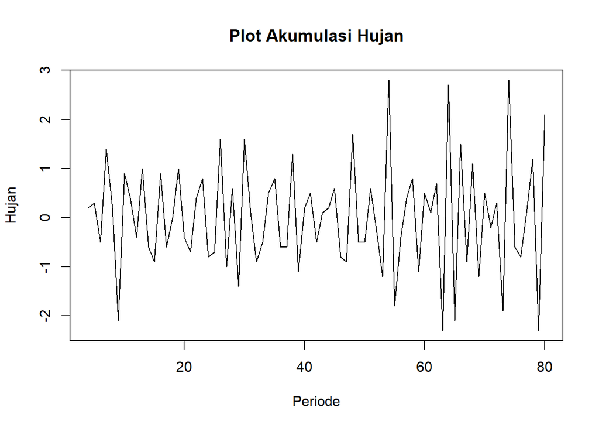

```r
train.diff<-diff(train.ts,differences = 3)
plot.ts(train.diff, lty=1, xlab="Periode", ylab="Hujan", main="Plot Akumulasi Hujan")
```

Berdasarkan plot data deret waktu, terlihat bahwa data sudah stasioner dalam rataan ditandai dengan data bergerak pada nilai rataan tertentu

```r
tseries::adf.test(train.diff)
```

```
##
##  Augmented Dickey-Fuller Test
##
## data:  train.diff
## Dickey-Fuller = -10.167, Lag order = 4, p-value = 0.01
## alternative hypothesis: stationary
```

$H_0$: Data tidak stasioner dalam rataan

$H_0$ : Data stasioner dalam rataan

Berdasarkan uji ADF tersebut, didapat p-value sebesar 0.01 yang kurang dari taraf nyata 5%, maka tolak $H_0$ dan menandakan bahwa data stasioner dalam rataan.

```r
tr.diff.bc <- train.diff + abs(min(train.diff)) + 1
tr.diff.bc
```

```
## Time Series:
## Start = 4
## End = 80
## Frequency = 1
##  [1] 3.5 3.6 2.8 4.7 3.5 1.2 4.2 3.7 2.9 4.3 2.7 2.4 4.2 2.7 3.3 4.3 2.9 2.6 3.7
## [20] 4.1 2.5 2.6 4.9 2.3 3.9 1.9 4.9 3.4 2.4 2.8 3.8 4.1 2.7 2.7 4.6 2.2 3.5 3.8
## [39] 2.8 3.4 3.5 3.9 2.5 2.4 5.0 2.8 2.8 3.9 3.0 2.1 6.1 1.5 2.9 3.7 4.1 2.2 3.8
## [58] 3.4 4.0 1.0 6.0 1.2 4.8 2.4 4.4 2.1 3.8 3.1 3.6 1.4 6.1 2.7 2.5 3.4 4.5 1.0
## [77] 5.4
```

Ditambahkan konstanta sehingga nilainya positif semua agar bisa dilakukan boxcox

```r
index2 <- seq(1:77)
bc = boxcox(tr.diff.bc~index2, lambda = seq(-2,5,by=1))
```

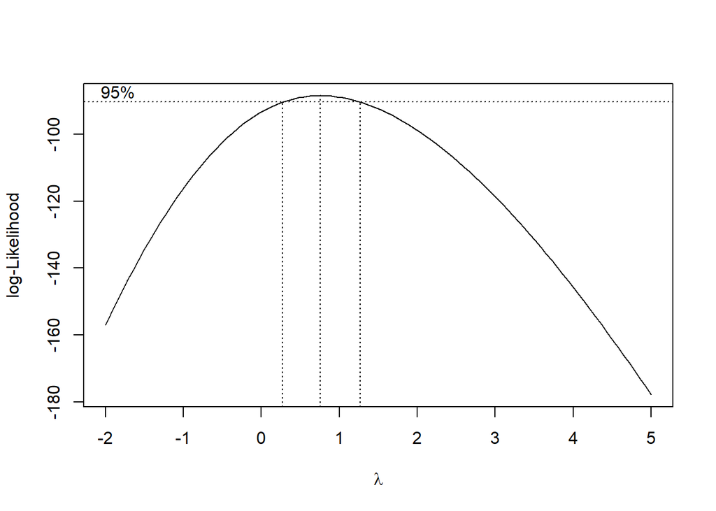

```r
lambda <- bc$x[which.max(bc$y)]
lambda
```

```
## [1] 0.7575758
```

```r
#Selang kepercayaan
bc$x[bc$y > max(bc$y) - 1/2 * qchisq(.95,1)]
```

```
##  [1] 0.3333333 0.4040404 0.4747475 0.5454545 0.6161616 0.6868687 0.7575758
##  [8] 0.8282828 0.8989899 0.9696970 1.0404040 1.1111111 1.1818182 1.2525253
```

#**Spesifikasi Model**

```r
eacf(train.diff)
```

```
## AR/MA
##   0 1 2 3 4 5 6 7 8 9 10 11 12 13
## 0 x o o o x x o o x x x  o  o  o
## 1 x o o o x o o o o o o  o  o  o
## 2 x o o x o o o o o o o  o  o  o
## 3 o x x o x o o o o o o  o  o  o
## 4 o x x o x o o o o o o  o  o  o
## 5 x x o x x o o o o o o  o  o  o
## 6 x x x o x o o x o o o  o  o  o
## 7 o x o o o o o o o o o  o  o  o
```

Menggunakan plot EACF, dapat diambil beberapa model dengan melihat ujung segitiga yang terbentuk, antara lain ARIMA (0,0,2), ARIMA(1,0,3), ARIMA(2,0,4), ARIMA(0,0,3), ARIMA(0,0,4), ARIMA(3,0,5)

#**Model ARIMA(0,0,2)**

```r
model1.da=Arima(train.diff, order=c(0,0,2),method="ML")
summary(model1.da)
```

```
## Series: train.diff
## ARIMA(0,0,2) with non-zero mean
##
## Coefficients:
##           ma1     ma2   mean
##       -1.9950  0.9992  1e-04
## s.e.   0.0514  0.0511  3e-04
##
## sigma^2 = 0.2018:  log likelihood = -52.48
## AIC=112.95   AICc=113.51   BIC=122.33
##
## Training set error measures:
##                      ME      RMSE       MAE           MPE         MAPE     MASE
## Training set 0.05432128 0.4404277 0.3484196 -6.979835e+13 6.979835e+13 0.220482
##                    ACF1
## Training set -0.1196445
```

```r
lmtest::coeftest(model1.da)
```

```
##
## z test of coefficients:
##
##              Estimate  Std. Error  z value Pr(>|z|)
## ma1       -1.9950e+00  5.1383e-02 -38.8253   <2e-16 ***
## ma2        9.9925e-01  5.1133e-02  19.5421   <2e-16 ***
## intercept  8.1563e-05  2.8493e-04   0.2863   0.7747
## ---
## Signif. codes:  0 '***' 0.001 '**' 0.01 '*' 0.05 '.' 0.1 ' ' 1
```

#**Model ARIMA(1,0,3)**

```r
model2.da=Arima(train.diff, order=c(1,0,3),method="ML")
summary(model2.da)
```

```
## Series: train.diff
## ARIMA(1,0,3) with non-zero mean
##
## Coefficients:
##           ar1      ma1      ma2     ma3   mean
##       -0.9938  -1.0353  -0.9172  0.9604  1e-04
## s.e.   0.0134   0.0664   0.0826  0.0646  3e-04
##
## sigma^2 = 0.192:  log likelihood = -49.97
## AIC=111.94   AICc=113.14   BIC=126.01
##
## Training set error measures:
##                      ME      RMSE     MAE           MPE         MAPE      MASE
## Training set 0.05554793 0.4237415 0.33393 -7.478877e+13 7.478877e+13 0.2113129
##                     ACF1
## Training set -0.02180069
```

```r
lmtest::coeftest(model2.da)
```

```
##
## z test of coefficients:
##
##              Estimate  Std. Error  z value Pr(>|z|)
## ar1       -9.9379e-01  1.3439e-02 -73.9473   <2e-16 ***
## ma1       -1.0353e+00  6.6414e-02 -15.5889   <2e-16 ***
## ma2       -9.1716e-01  8.2647e-02 -11.0974   <2e-16 ***
## ma3        9.6036e-01  6.4629e-02  14.8596   <2e-16 ***
## intercept  7.2475e-05  2.6701e-04   0.2714   0.7861
## ---
## Signif. codes:  0 '***' 0.001 '**' 0.01 '*' 0.05 '.' 0.1 ' ' 1
```

#**Model ARIMA(0,0,4)**

```r
model3.da=Arima(train.diff, order=c(0,0,4),method="ML")
summary(model3.da)
```

```
## Series: train.diff
## ARIMA(0,0,4) with non-zero mean
##
## Coefficients:
##           ma1     ma2     ma3      ma4   mean
##       -2.3149  1.3485  0.2542  -0.2868  0e+00
## s.e.   0.1631  0.2915  0.2567   0.1304  2e-04
##
## sigma^2 = 0.1757:  log likelihood = -48.25
## AIC=108.51   AICc=109.71   BIC=122.57
##
## Training set error measures:
##                      ME      RMSE       MAE           MPE         MAPE     MASE
## Training set 0.05690506 0.4053706 0.3349273 -7.656715e+13 7.656715e+13 0.211944
##                    ACF1
## Training set 0.04758365
```

```r
lmtest::coeftest(model3.da)
```

```
##
## z test of coefficients:
##
##              Estimate  Std. Error  z value  Pr(>|z|)
## ma1       -2.3149e+00  1.6311e-01 -14.1922 < 2.2e-16 ***
## ma2        1.3485e+00  2.9147e-01   4.6266 3.718e-06 ***
## ma3        2.5424e-01  2.5671e-01   0.9904   0.32199
## ma4       -2.8679e-01  1.3040e-01  -2.1992   0.02786 *
## intercept  3.6439e-05  1.6776e-04   0.2172   0.82804
## ---
## Signif. codes:  0 '***' 0.001 '**' 0.01 '*' 0.05 '.' 0.1 ' ' 1
```

#**Model ARIMA(3,0,5)**

```r
model4.da=Arima(train.diff, order=c(3,0,5),method="ML")
summary(model4.da)
```

```
## Series: train.diff
## ARIMA(3,0,5) with non-zero mean
##
## Coefficients:
##           ar1     ar2     ar3      ma1      ma2     ma3     ma4      ma5   mean
##       -1.0346  0.1242  0.2143  -1.1810  -1.5508  1.7652  0.8564  -0.8898  0e+00
## s.e.   0.1873  0.2246  0.1844   0.3594   0.2715  0.5801  0.2889   0.3281  1e-04
##
## sigma^2 = 0.1368:  log likelihood = -41.04
## AIC=102.08   AICc=105.42   BIC=125.52
##
## Training set error measures:
##                      ME      RMSE       MAE           MPE         MAPE
## Training set 0.06426398 0.3475991 0.2842553 -5.586837e+13 5.586837e+13
##                   MASE        ACF1
## Training set 0.1798785 -0.01268575
```

```r
lmtest::coeftest(model4.da)
```

```
##
## z test of coefficients:
##
##              Estimate  Std. Error z value  Pr(>|z|)
## ar1       -1.0346e+00  1.8731e-01 -5.5238 3.317e-08 ***
## ar2        1.2415e-01  2.2460e-01  0.5528  0.580415
## ar3        2.1432e-01  1.8437e-01  1.1625  0.245048
## ma1       -1.1810e+00  3.5938e-01 -3.2861  0.001016 **
## ma2       -1.5508e+00  2.7155e-01 -5.7109 1.124e-08 ***
## ma3        1.7652e+00  5.8006e-01  3.0432  0.002341 **
## ma4        8.5639e-01  2.8885e-01  2.9648  0.003029 **
## ma5       -8.8984e-01  3.2810e-01 -2.7121  0.006685 **
## intercept  3.1365e-05  1.4331e-04  0.2189  0.826755
## ---
## Signif. codes:  0 '***' 0.001 '**' 0.01 '*' 0.05 '.' 0.1 ' ' 1
```

#**Kesimpulan**

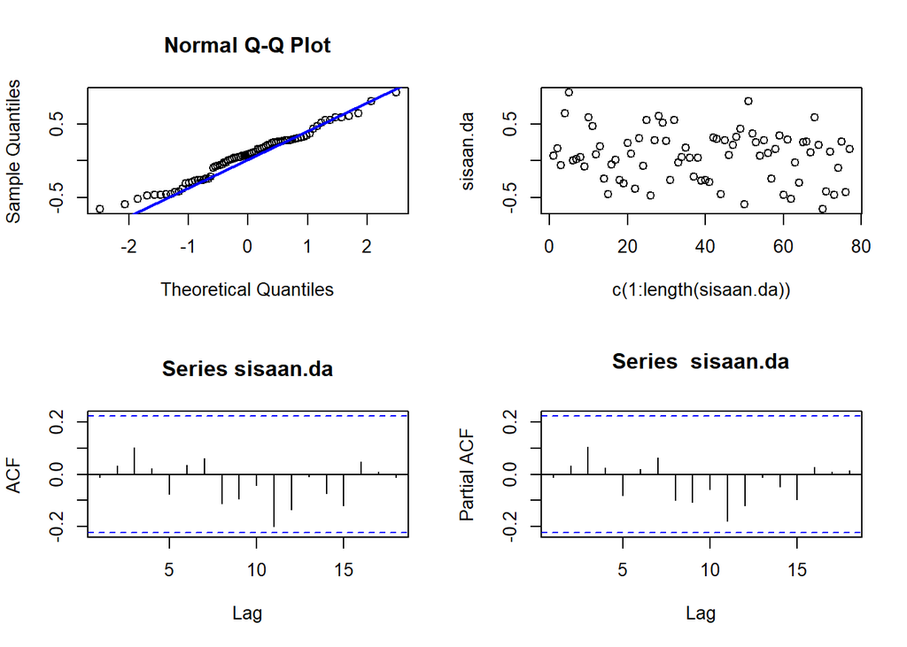

```r
sisaan.da <- model4.da$residuals
par(mfrow=c(2,2))
qqnorm(sisaan.da)
qqline(sisaan.da, col = "blue", lwd = 2)
plot(c(1:length(sisaan.da)),sisaan.da)
acf(sisaan.da)
pacf(sisaan.da)
```

```r
par(mfrow = c(1,1))
```

```r
#1) Sisaan Menyebar Normal
ks.test(sisaan.da,"pnorm")  #tak tolak H0 > sisaan menyebar normal
```

```
##
##  Exact one-sample Kolmogorov-Smirnov test
##
## data:  sisaan.da
## D = 0.27767, p-value = 9.674e-06
## alternative hypothesis: two-sided
```

Selain dengan eksplorasi, asumsi tersebut dapat diuji menggunakan uji formal. Pada tahapan ini uji formal yang digunakan untuk normalitas adalah uji Kolmogorov-Smirnov (KS). Hipotesis pada uji KS adalah sebagai berikut.

$H_0$ : Sisaan menyebar normal

$H_1$ : Sisaan tidak menyebar normal

Berdasarkan uji KS tersebut, didapat *p-value* sebesar 9.674e-06 yang kurang dari taraf nyata 5% sehingga tolak $H_0$ dan menandakan bahwa sisaan tidak menyebar normal. Berdasarkan hasil uji Kolmogorov-Smirnov, meskipun pada Q-Q plot terlihat mendekati garis 45∘, secara statistik sisaan tidak menyebar normal. Hal ini menunjukkan bahwa mungkin ada sedikit deviasi dari distribusi normal, dan ini bisa menjadi perhatian jika normalitas adalah asumsi penting dalam model Anda.

```r
#2) Sisaan saling bebas/tidak ada autokorelasi
Box.test(sisaan.da, type = "Ljung")  #tak tolak H0 > sisaan saling bebas
```

```
##
##  Box-Ljung test
##
## data:  sisaan.da
## X-squared = 0.012881, df = 1, p-value = 0.9096
```

$H_0$ : Sisaan saling bebas

$H_1$ : Sisaan tidak tidak saling bebas

Berdasarkan uji Ljung-Box tersebut, didapat *p-value* sebesar 0.9096 yang lebih besar dari taraf nyata 5% sehingga tak tolak $H_0$ dan menandakan bahwa sisaan saling bebas.

```r
#3) Sisaan homogen
Box.test((sisaan.da)^2, type = "Ljung")  #tak tolak H0 > sisaan homogen
```

```
##
##  Box-Ljung test
##
## data:  (sisaan.da)^2
## X-squared = 2.3382, df = 1, p-value = 0.1262
```

Hipotesis yang digunakan untuk uji kehomogenan ragam adalah sebagai berikut.

$H_0$ : Ragam sisaan homogen

$H_1$ : Ragam sisaan tidak homogen

```r
#4) Nilai tengah sisaan sama dengan nol
t.test(sisaan.da, mu = 0, conf.level = 0.95)  #tak tolak h0 > nilai tengah sisaan sama dengan 0
```

```
##
##  One Sample t-test
##
## data:  sisaan.da
## t = 1.64, df = 76, p-value = 0.1051
## alternative hypothesis: true mean is not equal to 0
## 95 percent confidence interval:
##  -0.0137797  0.1423077
## sample estimates:
##  mean of x
## 0.06426398
```

Terakhir, dengan uji-t, akan dicek apakah nilai tengah sisaan sama dengan nol. Hipotesis yang diujikan sebagai berikut.

$H_0$ : nilai tengah sisaan sama dengan 0

$H_1$ : nilai tengah sisaan tidak sama dengan 0

Berdasarkan uji-ttersebut, didapat *p-value* sebesar 0.1051 yang lebih besar dari taraf nyata 5% sehingga tak tolak $H_0$ dan menandakan bahwa nilai tengah sisaan sama dengan nol.

```r
#---FORECAST---#
ramalan.da <- forecast::forecast(model4.da, h = 30)
ramalan.da
```

```
##     Point Forecast      Lo 80      Hi 80     Lo 95      Hi 95
##  81    -0.93949448 -1.4296704 -0.4493186 -1.689154 -0.1898351
##  82     0.06605198 -1.0958666  1.2279706 -1.710949  1.8430531
##  83    -0.06766630 -1.2916715  1.1563389 -1.939621  1.8042881
##  84     0.38720364 -0.8958684  1.6702757 -1.575086  2.3494930
##  85    -0.53092317 -1.8234078  0.7615615 -2.507608  1.4457615
##  86     0.58294171 -0.7147486  1.8806320 -1.401704  2.5675877
##  87    -0.58601562 -1.8965845  0.7245532 -2.590358  1.4183264
##  88     0.56495850 -0.7669436  1.8968606 -1.472010  2.6019269
##  89    -0.53229834 -1.8862801  0.8216834 -2.603035  1.5384381
##  90     0.49533987 -0.8801262  1.8708059 -1.608254  2.5989337
##  91    -0.45745262 -1.8519987  0.9370935 -2.590227  1.6753216
##  92     0.42077035 -0.9903638  1.8319045 -1.737373  2.5789138
##  93    -0.38592790 -1.8111436  1.0392878 -2.565607  1.7937514
##  94     0.35355049 -1.0835304  1.7906314 -1.844275  2.5513761
```

[output cut: 16 more lines]

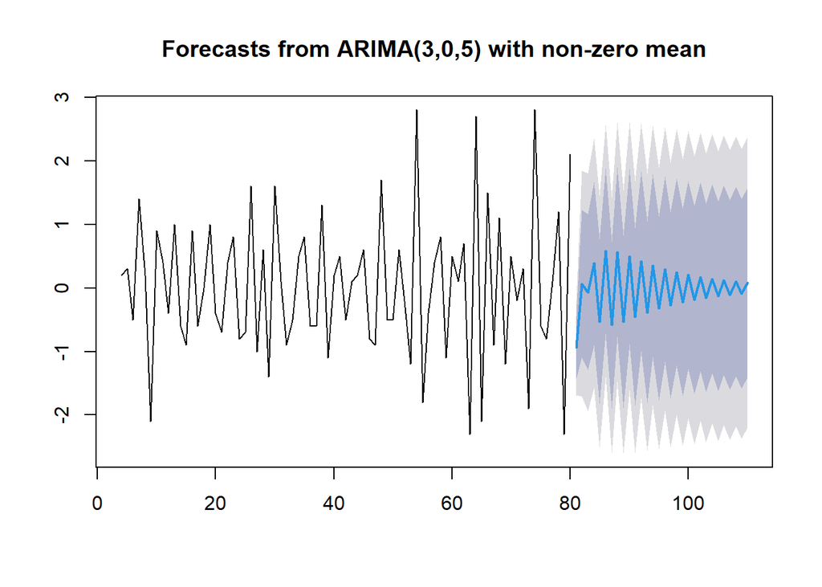

```r
data.ramalan.da <- ramalan.da$mean
plot(ramalan.da)
```

Berdasarkan hasil plot ramalan di atas, dapat dilihat bahwa ramalan ARIMA(3,0,5) cenderung stabil hingga akhir periode. Selanjutnya, dapat dicari nilai akurasi antara hasil ramalan dengan data uji sebagai berikut.

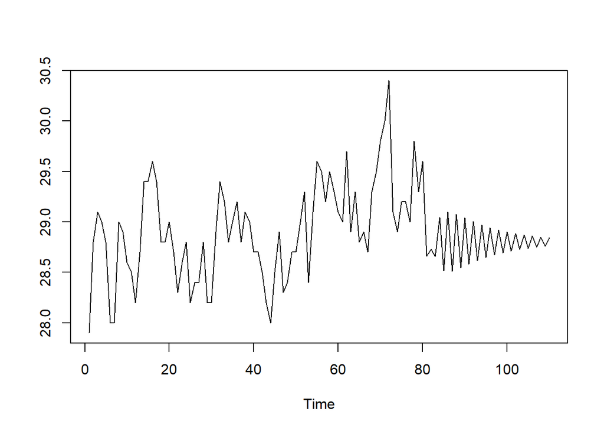

```r
pt_1 <- train.ts[55] #nilai akhir data latih
hasil.forc.Diff <- data.ramalan.da
hasil <- diffinv(hasil.forc.Diff, differences = 1) + pt_1
#has.1 sama hasilnta dengan: cumsum(c(pt_1,hasil.forc.Diff))
ts.plot(train.ts,hasil)
```

```r
perbandingan.da<-matrix(data=c(head(test.ts, n=50), hasil[-1]),
                     nrow = 50, ncol = 2)
colnames(perbandingan.da)<-c("Aktual","Hasil Forecast")
perbandingan.da
```

```
##         Aktual Hasil Forecast
##  [1,] 29.70000       28.84268
##  [2,] 30.10000       29.70000
##  [3,] 30.70000       30.10000
##  [4,] 30.10000       30.70000
##  [5,] 30.20000       30.10000
##  [6,] 30.10000       30.20000
##  [7,] 30.30000       30.10000
##  [8,] 30.80000       30.30000
##  [9,] 30.10000       30.80000
## [10,] 31.80000       30.10000
## [11,] 30.30000       31.80000
## [12,] 30.70000       30.30000
## [13,] 29.90000       30.70000
## [14,] 30.20000       29.90000
```

[output cut: 36 more lines]

```r
accuracy(ts(hasil[-1]), head(test.ts, n=30))
```

```
##                ME    RMSE      MAE     MPE    MAPE      ACF1 Theil's U
## Test set 1.428326 1.50888 1.428326 4.70345 4.70345 0.1895694  2.296713
```